# Análisis evolución Covid-19 Chile casos y decesos (10/04/2020)

Claudio Bustos

10/4/2020

- Reportes anteriores: https://github.com/clbustos/analisis_covid19_chile

## Análisis de series de casos

La serie de casos se hace hace partir de los 20 casos, excepto para Atacama y Aysén, donde se inicia del quinto caso, para facilitar la comparación desde un punto de un punto de partida común, ya que la aparición de los primeros casos siempre es un tanto errática. La serie de datos total tiene un patrón en 4 fases, las dos primeras de ascenso prácticamente exponencial (días 0 a 10, y 10 a 14), una también exponencial con menor tasa (14-20) y la actual, que parece haberse estancado en una tasa menor a los periodos anteriores en la última semana.

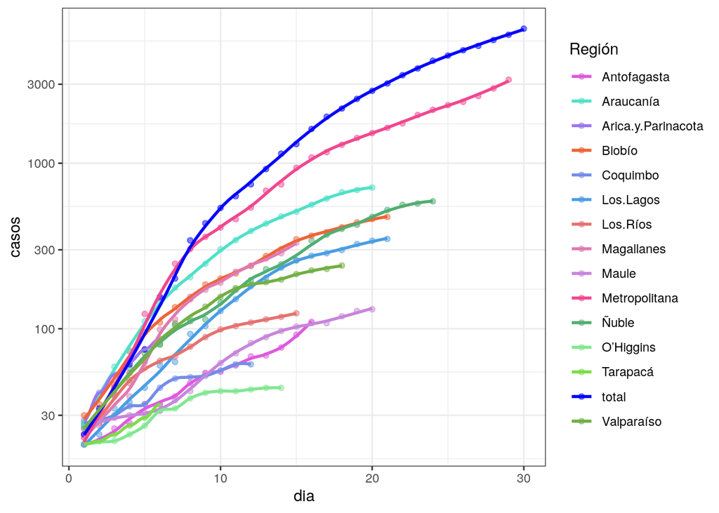

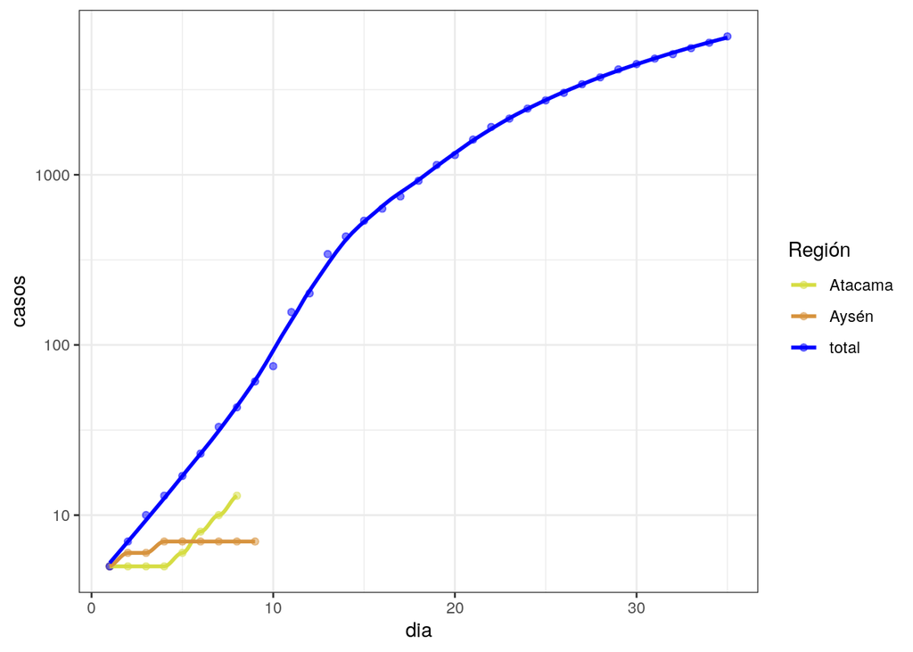

La serie por región se hace partir de los 5 primeros casos.

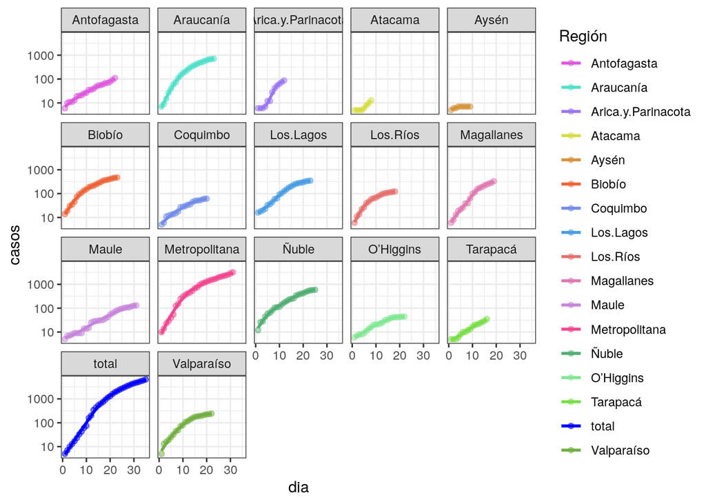

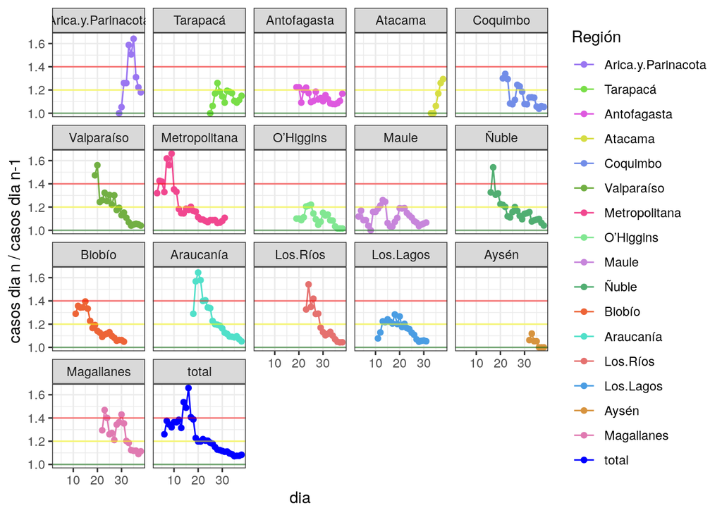

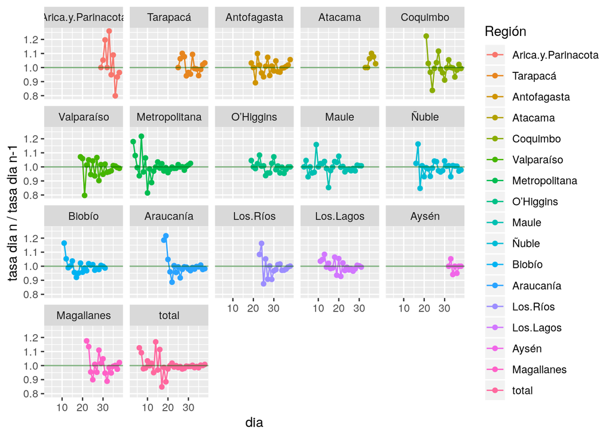

## Predicción

### Predicción para serie total

Recordemos que la regresión exponencial se eliminó, porque ya no calza con la serie total. A partir del análisis del resultado del algoritmo de la última semana, para la predicción total se recorta la serie a partir de lo 50 casos.

- tendencia sobre casos nuevos + AR(1) y sobre AR(4): Se modela la tendencia de los casos nuevos usando regresión exponencial, con regresión cuadradática, más la relación que existe entre mediciones contiguas. Se prueban dos modelos, uno que considera la relación solo entre cada tiempo y el anterior, AR(1), y un modelo más a largo plazo, que considera periodos de 4 días consecutivos, AR(4) . El error estándar aumenta a lo largo del tiempo, tanto por el error al calcular la tendencia, como por el componente autorregresivo. El valor medio obtenido es bastante sensible a los cambios en las mediciones finales.
- ARIMA(1,1,0) más deriva: Se ocupa un modelo autorregresivo, con diferenciación y deriva. Esto implica que se asume que los datos tienen una tendencia constante (como el modelo de regresión exponencial), pero se modela la relación que existe entre casos contiguos (como el modelo de tendencia). Tiende a generar modelos menos variables que el de tendencia + AR(1), pero asume que la curva de crecimiento es la misma de toda la serie de datos.

Para el día de hoy, la predicción AR(1) es más pesimista que la AR(4), posiblemente por el aumento de tasa del día de hoy. El modelo AR(4), al tomar en cuenta más mediciones para hacer el ajuste de los errores, controla que el cambio sea solo un shock del día.

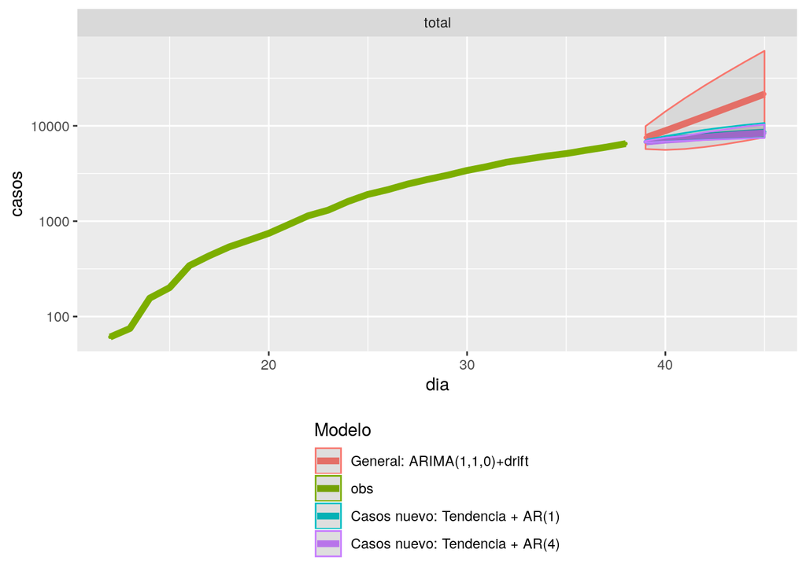

Casos nuevos: tendencia + AR(4) : total

|  | dia | casos | li | ls |
| --- | --- | --- | --- | --- |
| **28** | 39 | 6775 | 6668 | 6951 |
| **29** | 40 | 7081 | 6842 | 7489 |
| **30** | 41 | 7293 | 6958 | 7874 |
| **31** | 42 | 7611 | 7108 | 8551 |
| **32** | 43 | 7883 | 7232 | 9148 |
| **33** | 44 | 8186 | 7369 | 9817 |
| **34** | 45 | 8392 | 7457 | 10299 |

Casos nuevos: tendencia + AR(1) : total

|  | dia | casos | li | ls |
| --- | --- | --- | --- | --- |
| **28** | 39 | 6794 | 6662 | 7034 |
| **29** | 40 | 7179 | 6855 | 7804 |
| **30** | 41 | 7482 | 7002 | 8427 |
| **31** | 42 | 7798 | 7155 | 9083 |
| **32** | 43 | 8075 | 7287 | 9657 |
| **33** | 44 | 8338 | 7414 | 10206 |
| **34** | 45 | 8573 | 7526 | 10695 |

ARIMA(1,1,0) con deriva : total

|  | dia | casos | li | ls |
| --- | --- | --- | --- | --- |
| **28** | 39 | 7521 | 5706 | 9913 |
| **29** | 40 | 8888 | 5591 | 14127 |
| **30** | 41 | 10580 | 5715 | 19586 |
| **31** | 42 | 12627 | 6001 | 26568 |
| **32** | 43 | 15083 | 6415 | 35463 |
| **33** | 44 | 18023 | 6945 | 46775 |
| **34** | 45 | 21539 | 7587 | 61142 |

### Predicciones para serie total usando predicción por regiones.

Otro modelo posible de análisis es usar la suma de las predicciones parciales por región. No he calculado los intervalos de confianza, porque para que sean adecuados debería considerar la covarianza entre las series de las distintas regiones.

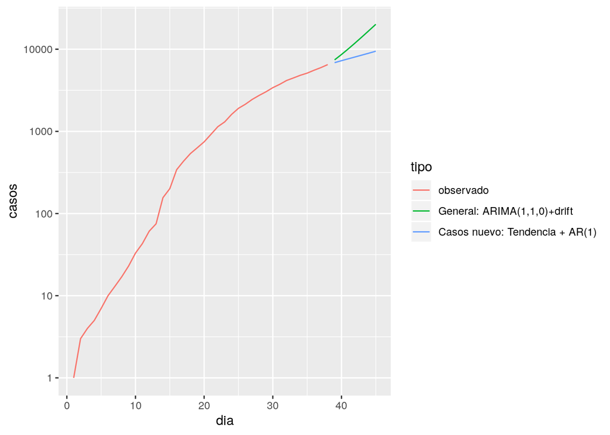

| dia | tipo | casos |
| --- | --- | --- |
| 1 | observado | 1 |
| 2 | observado | 3 |
| 3 | observado | 4 |
| 4 | observado | 5 |
| 5 | observado | 7 |
| 6 | observado | 10 |
| 7 | observado | 13 |
| 8 | observado | 17 |
| 9 | observado | 23 |
| 10 | observado | 33 |
| 11 | observado | 43 |
| 12 | observado | 61 |
| 13 | observado | 75 |
| 14 | observado | 156 |
| 15 | observado | 201 |
| 16 | observado | 342 |
| 17 | observado | 434 |
| 18 | observado | 537 |
| 19 | observado | 632 |
| 20 | observado | 746 |
| 21 | observado | 922 |
| 22 | observado | 1142 |
| 23 | observado | 1306 |
| 24 | observado | 1610 |
| 25 | observado | 1909 |
| 26 | observado | 2139 |
| 27 | observado | 2449 |
| 28 | observado | 2738 |
| 29 | observado | 3031 |
| 30 | observado | 3404 |
| 31 | observado | 3737 |
| 32 | observado | 4161 |
| 33 | observado | 4471 |
| 34 | observado | 4815 |
| 35 | observado | 5116 |
| 36 | observado | 5546 |
| 37 | observado | 5972 |
| 38 | observado | 6501 |
| 39 | General: ARIMA(1,1,0)+drift | 7424 |
| 40 | General: ARIMA(1,1,0)+drift | 8620 |
| 41 | General: ARIMA(1,1,0)+drift | 10111 |
| 42 | General: ARIMA(1,1,0)+drift | 11937 |
| 43 | General: ARIMA(1,1,0)+drift | 14157 |
| 44 | General: ARIMA(1,1,0)+drift | 16849 |
| 45 | General: ARIMA(1,1,0)+drift | 20107 |
| 39 | Casos nuevo: Tendencia + AR(1) | 6862 |
| 40 | Casos nuevo: Tendencia + AR(1) | 7251 |
| 41 | Casos nuevo: Tendencia + AR(1) | 7647 |
| 42 | Casos nuevo: Tendencia + AR(1) | 8059 |
| 43 | Casos nuevo: Tendencia + AR(1) | 8493 |
| 44 | Casos nuevo: Tendencia + AR(1) | 8958 |
| 45 | Casos nuevo: Tendencia + AR(1) | 9465 |

### Predicción por regiones

Hemos modificado el algoritmo para iniciar desde 3 casos en cada Región . En Atacama AR(1) es muy pesimista, por el incremento acelerado de los últimos días.

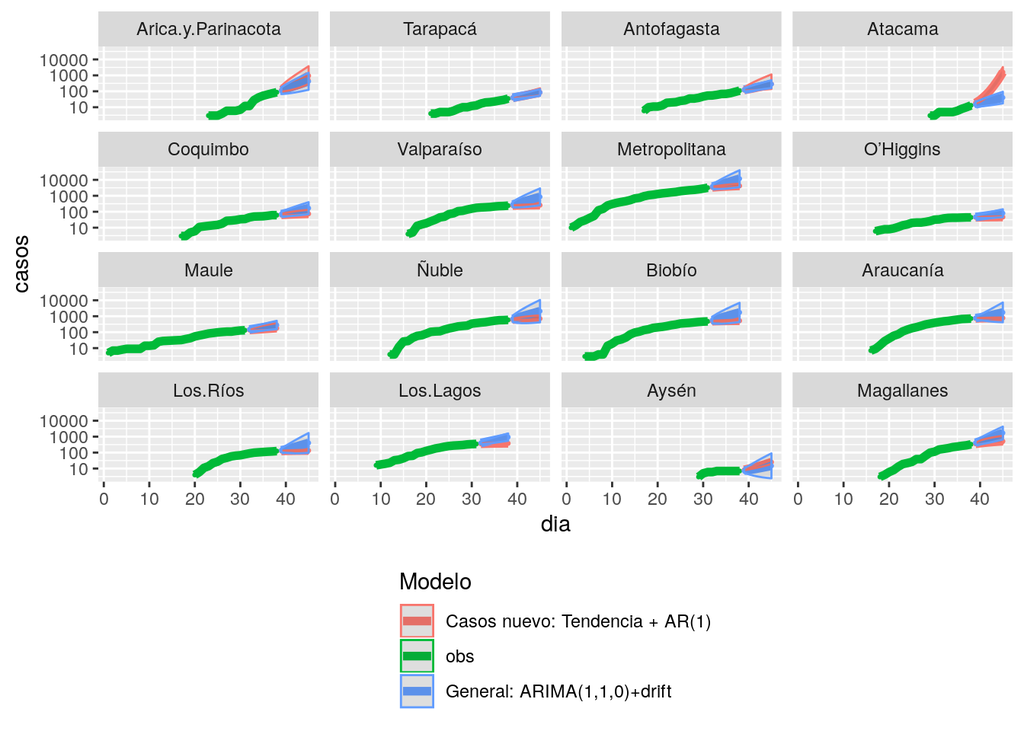

Las tablas por regiones se incluye en el Anexo I

## Decesos

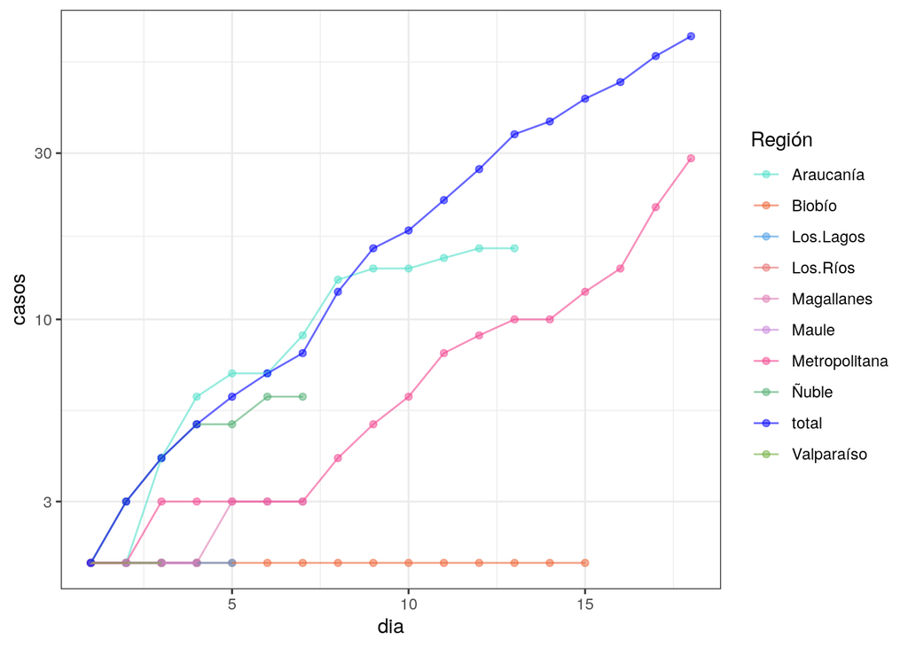

**Fuentes de información**: Principalmente, se utilizó el reporte diario del [MINSAL](https://www.minsal.cl/nuevo-coronavirus-2019-ncov/casos-confirmados-en-chile-covid-19/), usando [Wayback machine](https://archive.org/web/) para recopilar la información ya no disponible.

## Anexo I: Predicciones por región

Casos nuevos: tendencia + AR(1) : Arica.y.Parinacota

|  | dia | casos | li | ls |
| --- | --- | --- | --- | --- |
| **17** | 39 | 118 | 94.36 | 217.3 |
| **18** | 40 | 158.6 | 103.9 | 390.7 |
| **19** | 41 | 218.3 | 117.8 | 645.9 |
| **20** | 42 | 306.1 | 138.4 | 1021 |
| **21** | 43 | 437.6 | 169.2 | 1583 |
| **22** | 44 | 637.3 | 215.9 | 2437 |
| **23** | 45 | 945.1 | 287.9 | 3753 |

Casos nuevos: tendencia + AR(1) : Tarapacá

|  | dia | casos | li | ls |
| --- | --- | --- | --- | --- |
| **19** | 39 | 38.93 | 36.67 | 44.28 |
| **20** | 40 | 44.01 | 38.78 | 56.45 |
| **21** | 41 | 49.75 | 41.18 | 70.24 |
| **22** | 42 | 56.48 | 43.98 | 86.4 |
| **23** | 43 | 64.37 | 47.26 | 105.3 |
| **24** | 44 | 73.68 | 51.14 | 127.7 |
| **25** | 45 | 84.74 | 55.75 | 154.2 |

Casos nuevos: tendencia + AR(1) : Antofagasta

|  | dia | casos | li | ls |
| --- | --- | --- | --- | --- |
| **23** | 39 | 120.7 | 111.9 | 169.8 |
| **24** | 40 | 136.1 | 114.6 | 259.7 |
| **25** | 41 | 154.3 | 117.7 | 366.1 |
| **26** | 42 | 177.1 | 121.6 | 499.3 |
| **27** | 43 | 205.6 | 126.4 | 665.8 |
| **28** | 44 | 241.5 | 132.6 | 876.3 |
| **29** | 45 | 287.5 | 140.4 | 1145 |

Casos nuevos: tendencia + AR(1) : Atacama

|  | dia | casos | li | ls |
| --- | --- | --- | --- | --- |
| **11** | 39 | 18.75 | 16.58 | 22.25 |
| **12** | 40 | 28.5 | 21.91 | 40.07 |
| **13** | 41 | 50.2 | 33.02 | 82.44 |
| **14** | 42 | 96.73 | 55.97 | 176.8 |
| **15** | 43 | 219.2 | 115.1 | 430.7 |
| **16** | 44 | 547 | 271.2 | 1119 |
| **17** | 45 | 1579 | 759 | 3304 |

Casos nuevos: tendencia + AR(1) : Coquimbo

|  | dia | casos | li | ls |
| --- | --- | --- | --- | --- |
| **23** | 39 | 63.5 | 61.47 | 74.21 |
| **24** | 40 | 65.52 | 61.85 | 85.18 |
| **25** | 41 | 67.49 | 62.21 | 95.85 |
| **26** | 42 | 69.33 | 62.55 | 105.8 |
| **27** | 43 | 71.06 | 62.87 | 115.2 |
| **28** | 44 | 72.65 | 63.16 | 123.8 |
| **29** | 45 | 74.12 | 63.43 | 131.8 |

Casos nuevos: tendencia + AR(1) : Valparaíso

|  | dia | casos | li | ls |
| --- | --- | --- | --- | --- |
| **24** | 39 | 244.8 | 242.3 | 251.5 |
| **25** | 40 | 249.2 | 243.8 | 265.1 |
| **26** | 41 | 252 | 244.7 | 274.1 |
| **27** | 42 | 254.3 | 245.4 | 281.4 |
| **28** | 43 | 256 | 245.9 | 286.6 |
| **29** | 44 | 257.2 | 246.3 | 290.4 |
| **30** | 45 | 258 | 246.6 | 293.1 |

Casos nuevos: tendencia + AR(1) : Metropolitana

|  | dia | casos | li | ls |
| --- | --- | --- | --- | --- |
| **32** | 32 | 3383 | 3266 | 3686 |
| **33** | 33 | 3544 | 3327 | 4111 |
| **34** | 34 | 3691 | 3383 | 4501 |
| **35** | 35 | 3828 | 3435 | 4861 |
| **36** | 36 | 3953 | 3482 | 5191 |
| **37** | 37 | 4066 | 3525 | 5491 |
| **38** | 38 | 4168 | 3563 | 5760 |

Casos nuevos: tendencia + AR(1) : O’Higgins

|  | dia | casos | li | ls |
| --- | --- | --- | --- | --- |
| **23** | 39 | 44.66 | 44.22 | 45.98 |
| **24** | 40 | 45.18 | 44.39 | 47.55 |
| **25** | 41 | 45.58 | 44.52 | 48.76 |
| **26** | 42 | 45.88 | 44.62 | 49.67 |
| **27** | 43 | 46.1 | 44.7 | 50.34 |
| **28** | 44 | 46.26 | 44.75 | 50.82 |
| **29** | 45 | 46.37 | 44.79 | 51.16 |

Casos nuevos: tendencia + AR(1) : Maule

|  | dia | casos | li | ls |
| --- | --- | --- | --- | --- |
| **32** | 32 | 136.5 | 132.1 | 157.9 |
| **33** | 33 | 142.9 | 133.4 | 190.2 |
| **34** | 34 | 149.6 | 134.7 | 224.2 |
| **35** | 35 | 156.5 | 136.1 | 258.9 |
| **36** | 36 | 163.5 | 137.5 | 294.3 |
| **37** | 37 | 170.6 | 138.9 | 330.2 |
| **38** | 38 | 177.7 | 140.3 | 366.5 |

Casos nuevos: tendencia + AR(1) : Ñuble

|  | dia | casos | li | ls |
| --- | --- | --- | --- | --- |
| **28** | 39 | 611.8 | 594 | 694.3 |
| **29** | 40 | 632 | 598.3 | 788.3 |
| **30** | 41 | 650.3 | 602.2 | 874 |
| **31** | 42 | 666.8 | 605.7 | 950.8 |
| **32** | 43 | 681.3 | 608.8 | 1019 |
| **33** | 44 | 694.1 | 611.5 | 1078 |
| **34** | 45 | 705.1 | 613.9 | 1130 |

Casos nuevos: tendencia + AR(1) : Biobío

|  | dia | casos | li | ls |
| --- | --- | --- | --- | --- |
| **29** | 32 | 486.2 | 478.7 | 505.8 |
| **30** | 33 | 496 | 482.4 | 531.5 |
| **31** | 34 | 503.8 | 485.4 | 551.8 |
| **32** | 35 | 509.8 | 487.7 | 567.5 |
| **33** | 36 | 514.4 | 489.5 | 579.3 |
| **34** | 37 | 517.7 | 490.7 | 588.1 |
| **35** | 38 | 520.1 | 491.7 | 594.5 |

Casos nuevos: tendencia + AR(1) : Araucanía

|  | dia | casos | li | ls |
| --- | --- | --- | --- | --- |
| **24** | 39 | 730.1 | 721.6 | 746.3 |
| **25** | 40 | 744.1 | 729 | 772.7 |
| **26** | 41 | 754.6 | 734.6 | 792.5 |
| **27** | 42 | 762.3 | 738.6 | 806.9 |
| **28** | 43 | 767.6 | 741.5 | 817 |
| **29** | 44 | 771.4 | 743.5 | 824 |
| **30** | 45 | 773.8 | 744.8 | 828.7 |

Casos nuevos: tendencia + AR(1) : Los.Ríos

|  | dia | casos | li | ls |
| --- | --- | --- | --- | --- |
| **20** | 39 | 126.7 | 125.2 | 129.9 |
| **21** | 40 | 129.2 | 126.3 | 135.6 |
| **22** | 41 | 131.1 | 127.2 | 139.7 |
| **23** | 42 | 132.5 | 127.8 | 142.9 |
| **24** | 43 | 133.5 | 128.2 | 145.2 |
| **25** | 44 | 134.2 | 128.6 | 146.8 |
| **26** | 45 | 134.7 | 128.8 | 148 |

Casos nuevos: tendencia + AR(1) : Los.Lagos

|  | dia | casos | li | ls |
| --- | --- | --- | --- | --- |
| **24** | 32 | 358.4 | 352.7 | 373 |
| **25** | 33 | 365 | 355 | 391.4 |
| **26** | 34 | 370.2 | 356.9 | 406.4 |
| **27** | 35 | 374.1 | 358.2 | 417.3 |
| **28** | 36 | 376.8 | 359.2 | 425.3 |
| **29** | 37 | 378.8 | 359.9 | 430.8 |
| **30** | 38 | 380.1 | 360.3 | 434.6 |

Casos nuevos: tendencia + AR(1) : Aysén

|  | dia | casos | li | ls |
| --- | --- | --- | --- | --- |
| **11** | 39 | 8.28 | 7.91 | 8.8 |
| **12** | 40 | 9.69 | 8.88 | 10.84 |
| **13** | 41 | 11.44 | 10.07 | 13.42 |
| **14** | 42 | 13.59 | 11.53 | 16.59 |
| **15** | 43 | 16.4 | 13.44 | 20.73 |
| **16** | 44 | 20.15 | 15.98 | 26.25 |
| **17** | 45 | 25.36 | 19.52 | 33.93 |

Casos nuevos: tendencia + AR(1) : Magallanes

|  | dia | casos | li | ls |
| --- | --- | --- | --- | --- |
| **22** | 39 | 357.2 | 337.4 | 438.7 |
| **23** | 40 | 387.4 | 344.3 | 570.6 |
| **24** | 41 | 415.5 | 350.7 | 693.7 |
| **25** | 42 | 442.7 | 356.9 | 813 |
| **26** | 43 | 468.3 | 362.7 | 924.9 |
| **27** | 44 | 491.9 | 368.1 | 1029 |
| **28** | 45 | 513.5 | 373.1 | 1123 |

ARIMA(1,1,0) con deriva : Arica.y.Parinacota

|  | dia | casos | li | ls |
| --- | --- | --- | --- | --- |
| **17** | 39 | 109.6 | 67.1 | 178.9 |
| **18** | 40 | 137.3 | 70.13 | 268.7 |
| **19** | 41 | 172 | 76.18 | 388.5 |
| **20** | 42 | 215.6 | 84.57 | 549.6 |
| **21** | 43 | 270.2 | 95.2 | 766.8 |
| **22** | 44 | 338.6 | 108.2 | 1059 |
| **23** | 45 | 424.3 | 124 | 1452 |

ARIMA(1,1,0) con deriva : Tarapacá

|  | dia | casos | li | ls |
| --- | --- | --- | --- | --- |
| **19** | 39 | 39.52 | 32.52 | 48.01 |
| **20** | 40 | 44.94 | 34.63 | 58.33 |
| **21** | 41 | 51.08 | 37.3 | 69.94 |
| **22** | 42 | 58.05 | 40.51 | 83.19 |
| **23** | 43 | 65.98 | 44.21 | 98.46 |
| **24** | 44 | 74.99 | 48.44 | 116.1 |
| **25** | 45 | 85.23 | 53.22 | 136.5 |

ARIMA(1,1,0) con deriva : Antofagasta

|  | dia | casos | li | ls |
| --- | --- | --- | --- | --- |
| **23** | 39 | 124.9 | 97.39 | 160.1 |
| **24** | 40 | 143.2 | 104 | 197.1 |
| **25** | 41 | 163.9 | 111.8 | 240.2 |
| **26** | 42 | 187.7 | 121.5 | 289.9 |
| **27** | 43 | 214.8 | 132.6 | 348 |
| **28** | 44 | 245.9 | 145.4 | 416 |
| **29** | 45 | 281.6 | 160 | 495.5 |

ARIMA(1,1,0) con deriva : Atacama

|  | dia | casos | li | ls |
| --- | --- | --- | --- | --- |
| **11** | 39 | 15.03 | 10.41 | 21.72 |
| **12** | 40 | 17.78 | 11.08 | 28.53 |
| **13** | 41 | 20.93 | 11.89 | 36.87 |
| **14** | 42 | 24.67 | 12.95 | 47 |
| **15** | 43 | 29.07 | 14.22 | 59.4 |
| **16** | 44 | 34.25 | 15.72 | 74.61 |
| **17** | 45 | 40.36 | 17.47 | 93.26 |

ARIMA(1,1,0) con deriva : Coquimbo

|  | dia | casos | li | ls |
| --- | --- | --- | --- | --- |
| **23** | 39 | 70.73 | 50.59 | 98.9 |
| **24** | 40 | 81.66 | 51.18 | 130.3 |
| **25** | 41 | 94.3 | 53.35 | 166.7 |
| **26** | 42 | 108.9 | 56.49 | 209.8 |
| **27** | 43 | 125.7 | 60.44 | 261.5 |
| **28** | 44 | 145.2 | 65.12 | 323.6 |
| **29** | 45 | 167.6 | 70.56 | 398.2 |

ARIMA(1,1,0) con deriva : Valparaíso

|  | dia | casos | li | ls |
| --- | --- | --- | --- | --- |
| **24** | 39 | 283.9 | 190.8 | 422.5 |
| **25** | 40 | 340.6 | 185.6 | 625.3 |
| **26** | 41 | 409.8 | 190.3 | 882.7 |
| **27** | 42 | 493.3 | 200.6 | 1213 |
| **28** | 43 | 593.8 | 215.1 | 1639 |
| **29** | 44 | 714.8 | 233.4 | 2189 |
| **30** | 45 | 860.5 | 255.5 | 2897 |

ARIMA(1,1,0) con deriva : Metropolitana

|  | dia | casos | li | ls |
| --- | --- | --- | --- | --- |
| **32** | 32 | 3767 | 2769 | 5124 |
| **33** | 33 | 4522 | 2672 | 7651 |
| **34** | 34 | 5465 | 2695 | 11081 |
| **35** | 35 | 6621 | 2801 | 15651 |
| **36** | 36 | 8031 | 2974 | 21687 |
| **37** | 37 | 9745 | 3205 | 29626 |
| **38** | 38 | 11826 | 3494 | 40032 |

ARIMA(1,1,0) con deriva : O’Higgins

|  | dia | casos | li | ls |
| --- | --- | --- | --- | --- |
| **23** | 39 | 46.79 | 40.2 | 54.47 |
| **24** | 40 | 50.83 | 39.41 | 65.58 |
| **25** | 41 | 55.63 | 39.67 | 78.01 |
| **26** | 42 | 61.03 | 40.58 | 91.81 |
| **27** | 43 | 67.02 | 41.93 | 107.1 |
| **28** | 44 | 73.62 | 43.63 | 124.2 |
| **29** | 45 | 80.87 | 45.63 | 143.3 |

ARIMA(1,1,0) con deriva : Maule

|  | dia | casos | li | ls |
| --- | --- | --- | --- | --- |
| **32** | 32 | 147.4 | 114.8 | 189.3 |
| **33** | 33 | 164.1 | 117.6 | 229.1 |
| **34** | 34 | 182.9 | 122.4 | 273.5 |
| **35** | 35 | 203.9 | 128.7 | 323 |
| **36** | 36 | 227.2 | 136.2 | 379 |
| **37** | 37 | 253.2 | 144.8 | 442.6 |
| **38** | 38 | 282.2 | 154.6 | 515.1 |

ARIMA(1,1,0) con deriva : Ñuble

|  | dia | casos | li | ls |
| --- | --- | --- | --- | --- |
| **28** | 39 | 682.9 | 423.8 | 1100 |
| **29** | 40 | 815.4 | 379.4 | 1753 |
| **30** | 41 | 981.1 | 364.5 | 2641 |
| **31** | 42 | 1183 | 364.4 | 3838 |
| **32** | 43 | 1426 | 373.8 | 5443 |
| **33** | 44 | 1721 | 390.1 | 7587 |
| **34** | 45 | 2075 | 412.5 | 10441 |

ARIMA(1,1,0) con deriva : Biobío

|  | dia | casos | li | ls |
| --- | --- | --- | --- | --- |
| **29** | 32 | 565.1 | 345.1 | 925.5 |
| **30** | 33 | 680.5 | 330.6 | 1401 |
| **31** | 34 | 820.1 | 335 | 2007 |
| **32** | 35 | 988.3 | 349.3 | 2796 |
| **33** | 36 | 1191 | 370.7 | 3826 |
| **34** | 37 | 1435 | 398.4 | 5171 |
| **35** | 38 | 1730 | 432.2 | 6922 |

ARIMA(1,1,0) con deriva : Araucanía

|  | dia | casos | li | ls |
| --- | --- | --- | --- | --- |
| **24** | 39 | 762.8 | 628.3 | 926 |
| **25** | 40 | 840.3 | 565.9 | 1248 |
| **26** | 41 | 946.1 | 515.4 | 1737 |
| **27** | 42 | 1083 | 476.7 | 2462 |
| **28** | 43 | 1257 | 448.6 | 3520 |
| **29** | 44 | 1473 | 429.4 | 5051 |
| **30** | 45 | 1740 | 417.5 | 7248 |

ARIMA(1,1,0) con deriva : Los.Ríos

|  | dia | casos | li | ls |
| --- | --- | --- | --- | --- |
| **20** | 39 | 138.9 | 104.8 | 184 |
| **21** | 40 | 161.2 | 95.64 | 271.7 |
| **22** | 41 | 190.9 | 90.79 | 401.5 |
| **23** | 42 | 228.7 | 89.13 | 587 |
| **24** | 43 | 275.8 | 89.85 | 846.5 |
| **25** | 44 | 333.7 | 92.48 | 1204 |
| **26** | 45 | 404.7 | 96.75 | 1693 |

ARIMA(1,1,0) con deriva : Los.Lagos

|  | dia | casos | li | ls |
| --- | --- | --- | --- | --- |
| **24** | 32 | 403.1 | 328.6 | 494.4 |
| **25** | 33 | 463.8 | 349.1 | 616.1 |
| **26** | 34 | 533.6 | 377.5 | 754.3 |
| **27** | 35 | 614 | 412.1 | 914.7 |
| **28** | 36 | 706.5 | 452.8 | 1102 |
| **29** | 37 | 812.9 | 499.6 | 1323 |
| **30** | 38 | 935.4 | 553 | 1582 |

ARIMA(1,1,0) con deriva : Aysén

|  | dia | casos | li | ls |
| --- | --- | --- | --- | --- |
| **11** | 39 | 7.37 | 5.33 | 10.19 |
| **12** | 40 | 8.02 | 4.33 | 14.86 |
| **13** | 41 | 8.9 | 3.64 | 21.81 |
| **14** | 42 | 10.01 | 3.16 | 31.72 |
| **15** | 43 | 11.34 | 2.82 | 45.5 |
| **16** | 44 | 12.9 | 2.59 | 64.28 |
| **17** | 45 | 14.72 | 2.42 | 89.51 |

ARIMA(1,1,0) con deriva : Magallanes

|  | dia | casos | li | ls |
| --- | --- | --- | --- | --- |
| **22** | 39 | 413.5 | 303.7 | 563.1 |
| **23** | 40 | 522.1 | 327 | 833.6 |
| **24** | 41 | 660.2 | 366.4 | 1190 |
| **25** | 42 | 835 | 419.1 | 1663 |
| **26** | 43 | 1056 | 485.7 | 2296 |
| **27** | 44 | 1336 | 567.8 | 3142 |
| **28** | 45 | 1689 | 668.2 | 4271 |